# Prediction of cancer disease by machine learning

In this project, I aimed to predict cancer levels using available clinicopathological parameters. To compare the performance of different machine learning frameworks and algorithms, I utilized both TensorFlow in Python and caret in R.

TensorFlow and caret are both machine learning frameworks that are used for building and training predictive models. However, they have some differences in terms of their design, implementation, and use cases.

TensorFlow is a powerful open-source framework developed by Google that is primarily used for deep learning applications. It allows users to build complex neural networks and train them on large datasets using distributed computing. TensorFlow is known for its flexibility, scalability, and high performance.

Caret is a machine learning package for R that provides a wide range of algorithms and tools for building predictive models. Caret is designed to be easy to use and provides a unified interface for training, testing, and tuning models. It supports a variety of machine-learning techniques, including regression, classification, and clustering.

For their strengths and weaknesses, TensorFlow is often preferred for deep learning tasks that require large amounts of data and complex architectures. Caret is more suitable for traditional machine-learning problems that involve smaller datasets and simpler models. However, both frameworks can be used for a wide range of applications and are widely used in industry and academia.

I carried out the coding for this project under the Rstudio platform (2022.07.2 Build 576) as it allowed the implementation of both python and R. This made side-by-side comparison easier. However, the code script of Tensorflow fully worked in JupyterLab (Version 3.4.5-1) as well.

# TensorFlow

## Import Libraries

```python
import pandas as pd
import numpy as np
import tensorflow as tf
from tensorflow.keras import datasets, layers, models
from tensorflow.keras.utils import to_categorical ## converting categorical variables into one-hot encoded vectors.
from sklearn.preprocessing import LabelEncoder ## converting categorical labels into numerical values.
from sklearn.model_selection import train_test_split ## splitting a dataset into training and testing subsets.
from sklearn.metrics import mean_squared_error

print(tf.__version__)
```

```
2.11.0
```

## Load the data

```python
df = pd.read_csv("cancer patient data sets.csv", sep=",")
df.head()
```

```
  Patient Id  Age  Gender  ...  Dry Cough  Snoring   Level
0         P1   33       1  ...          3        4     Low
1        P10   17       1  ...          7        2  Medium
2       P100   35       1  ...          7        2    High
3      P1000   37       1  ...          7        5    High
4       P101   46       1  ...          2        3    High

[5 rows x 25 columns]
```

```python
list(df.columns)
```

```
['Patient Id', 'Age', 'Gender', 'Air Pollution', 'Alcohol use', 'Dust Allergy', 'OccuPational Hazards', 'Genetic Risk', 'chronic Lung Disease', 'Balanced Diet', 'Obesity', 'Smoking', 'Passive Smoker', 'Chest Pain', 'Coughing of Blood', 'Fatigue', 'Weight Loss', 'Shortness of Breath', 'Wheezing', 'Sw…
```

## Creat the input features “X” and the target variable “y”

During this process, the ‘Patient Id’ was excluded as it is not a predictor.

```python
X = df.iloc[:,1:24].values
y = df.iloc[:,24].values

# Print first five X and y
print(X[0:5])
```

```
[[33  1  2  4  5  4  3  2  2  4  3  2  2  4  3  4  2  2  3  1  2  3  4]
 [17  1  3  1  5  3  4  2  2  2  2  4  2  3  1  3  7  8  6  2  1  7  2]
 [35  1  4  5  6  5  5  4  6  7  2  3  4  8  8  7  9  2  1  4  6  7  2]
 [37  1  7  7  7  7  6  7  7  7  7  7  7  8  4  2  3  1  4  5  6  7  5]
 [46  1  6  8  7  7  7  6  7  7  8  7  7  9  3  2  4  1  4  2  4  2  3]]
```

```python
print(y[0:5])
```

```
['Low' 'Medium' 'High' 'High' 'High']
```

```python
# Output:
print(X.shape)
```

```
(1000, 23)
```

```python
print(y.shape)
```

```
(1000,)
```

## Convert the target into LabelEncoder

This step was to encode the categorical target variables, where each category is represented by a unique integer label. This was realized by using the LabelEncoder class from the sklearn.preprocessing module.

```python
encoder =  LabelEncoder()
y1 = encoder.fit_transform(y)
print(y1[0:5])
```

```
[1 2 0 0 0]
```

## Convert the target into one hot encoding

After label encoding, the categorical variables were converted into a set of binary indicator variables. This step is crucial for target variables with non-ordered categories since label encoding can wrongly assume that the categories have an inherent order.

```python
Y = pd.get_dummies(y1).values
print(Y[0:5])
```

```
[[0 1 0]
 [0 0 1]
 [1 0 0]
 [1 0 0]
 [1 0 0]]
```

## Convert X and Y into train and test data

```python
x_train, x_test, y_train, y_test = train_test_split(X, Y, test_size=0.2, random_state=0)

print(x_train[0:5])
```

```
[[53  2  4  5  6  5  5  4  6  7  2  3  4  8  8  7  9  2  1  4  6  7  2]
 [52  1  3  2  1  2  3  5  1  2  7  2  1  1  1  1  1  3  2  3  2  3  3]
 [18  2  6  8  7  7  7  6  7  7  8  7  7  9  3  2  4  1  4  2  4  2  3]
 [53  1  3  1  4  2  3  2  3  3  2  2  4  2  2  2  3  4  1  5  2  6  2]
 [27  1  3  1  4  3  2  3  4  3  1  4  3  1  3  2  2  4  2  2  3  4  3]]
```

```python
print(y_train[0:5])
```

```
[[1 0 0]
 [0 1 0]
 [1 0 0]
 [0 1 0]
 [0 1 0]]
```

```python
print(x_test[0:5])
```

```
[[37  2  7  7  7  7  6  7  7  7  7  7  7  8  4  2  3  1  4  5  6  7  5]
 [48  2  6  8  7  7  7  6  2  4  1  2  4  3  2  7  6  5  1  9  3  4  2]
 [23  1  3  2  4  2  3  2  3  3  2  2  3  3  4  5  6  5  5  4  6  5  4]
 [25  2  4  5  6  5  5  4  6  7  2  3  4  8  8  7  9  2  1  4  6  7  2]
 [33  1  2  4  5  4  3  2  2  4  3  2  2  4  3  4  2  2  3  1  2  3  4]]
```

```python
print(y_test[0:5])
```

```
[[1 0 0]
 [0 0 1]
 [0 0 1]
 [1 0 0]
 [0 1 0]]
```

## Define a model

The model has two hidden layers with 10 neurons each and ReLU activation function, and an output layer with 3 neurons and softmax activation function. ReLU (Rectified Linear Unit) is an activation function commonly used in neural networks for deep learning, which returns the input value if it is positive, and zero otherwise. Softmax is a mathematical function that is commonly used as the activation function for the output layer in multi-class classification problems. It is a generalization of the logistic function, which can only output values between 0 and 1, to multiple classes.

```python
model = tf.keras.Sequential([
    tf.keras.layers.Dense(10, activation='relu'),
    tf.keras.layers.Dense(10, activation='relu'),
    tf.keras.layers.Dense(3, activation='softmax')
  ])
```

```
2023-03-02 12:50:38.684076: I tensorflow/core/platform/cpu_feature_guard.cc:193] This TensorFlow binary is optimized with oneAPI Deep Neural Network Library (oneDNN) to use the following CPU instructions in performance-critical operations:  AVX AVX2
To enable them in other operations, rebuild TensorFlow with the appropriate compiler flags.
```

```python
model
```

```
<keras.engine.sequential.Sequential object at 0x000001E722569F10>
```

## Compile the model

Among the parameters, ‘rmsprop’ is an optimization algorithm that is commonly used for training neural networks. It is an extension of the gradient descent algorithm that adapts the learning rate of each weight parameter based on the root-mean-square (RMS) gradients. The loss function ‘categorical_crossentropy’ is used in multiclass classification problems, where the goal is to predict the probability of each class label. It is defined as the negative logarithm of the predicted probability of the true class label: ‘loss = -log(predicted_probability_of_true_class)’.

```python
model.compile(optimizer='rmsprop',
              loss='categorical_crossentropy',
              metrics=['accuracy'])
```

## Train the model

The number of epochs and the “batch_size” are hyperparameters that may be tuned to achieve better model performance.

```python
model.fit(x_train, y_train, batch_size=25, epochs=100)
```

```
<keras.callbacks.History object at 0x000001E724932BE0>
```

## Evaluate the model with test data

```python
loss, accuracy = model.evaluate(x_test, y_test, verbose=0)
print('Test loss:', loss)
```

```
Test loss: 0.03152226656675339
```

```python
print('Test accuracy:', accuracy)
```

```
Test accuracy: 0.9950000047683716
```

## Predict using the test data

```python
y_pred = model.predict(x_test)
y_pred
```

[output not shown]

[output cut: 145 more lines]

[output not shown]

## Calculate the RMSE

```python
actual = np.argmax(y_test,axis=1)
predicted = np.argmax(y_pred,axis=1)
print(f"Actual: {actual}")
```

```
Actual: [0 2 2 0 1 2 2 2 2 1 1 0 1 0 0 1 0 2 1 2 0 1 0 0 0 0 1 0 0 2 0 1 1 0 2 2 2
 1 0 1 2 0 2 2 2 1 1 0 0 2 0 2 1 0 2 2 1 1 0 0 1 0 0 0 2 2 1 0 0 0 2 2 2 2
 1 1 1 2 2 0 1 2 1 0 0 2 1 2 1 0 2 1 0 1 2 1 2 0 1 0 2 0 2 1 0 2 0 2 2 0 0
 0 0 2 1 1 2 1 1 2 0 2 0 1 1 2 1 1 1 1 1 2 1 1 0 2 1 2 2 0 2 1 2 2 1 0 1 1
 1 1 1 0 2 0 0 0 1 2 2 1 2 0 0 0 1 1 0 1 0 2 0 0 1 1 1 2 0 0 0 1 0 0 0 0 0
 1 1 1 0 0 0 1 0 0 0 2 1 0 0 1]
```

```python
print(f"Predicted: {predicted}")
```

```
Predicted: [0 2 2 0 1 2 2 2 2 1 1 0 1 0 0 1 0 2 1 2 0 1 0 0 0 0 1 0 0 2 0 1 1 0 2 2 2
 1 0 1 2 0 2 2 2 1 1 0 0 2 0 2 1 0 2 2 1 1 0 0 1 0 0 0 2 2 1 0 0 0 2 2 2 2
 1 1 1 2 2 0 1 2 1 0 0 2 1 2 0 0 2 1 0 1 2 1 2 0 1 0 2 0 2 1 0 2 0 2 2 0 0
 0 0 2 1 1 2 1 1 2 0 2 0 1 1 2 1 1 1 1 1 2 1 1 0 2 1 2 2 0 2 1 2 2 1 0 1 1
 1 1 1 0 2 0 0 0 1 2 2 1 2 0 0 0 1 1 0 1 0 2 0 0 1 1 1 2 0 0 0 1 0 0 0 0 0
 1 1 1 0 0 0 1 0 0 0 2 1 0 0 1]
```

```python
# Calculate the RMSE using mean_squared_error function from sklearn.metrics
rmse = np.sqrt(mean_squared_error(actual, predicted))

# Print the RMSE
print("RMSE:", "{:.4f}".format(rmse))
```

```
RMSE: 0.0707
```

## Calculate other performance matrics

```python
accuracy = tf.keras.metrics.Accuracy()
accuracy.update_state(actual, predicted)
```

```
<tf.Variable 'UnreadVariable' shape=() dtype=float32, numpy=200.0>
```

```python
print("Accuracy:", accuracy.result().numpy())
```

```
Accuracy: 0.995
```

```python
precision = tf.keras.metrics.Precision()
precision.update_state(actual, predicted)
print("Precision:", precision.result().numpy())
```

```
Precision: 1.0
```

# Caret

```r
#libraries
library(reticulate)
library(tidyverse)
library(janitor)
library(caret)

#rmse function
RMSE <- function(true_value, predicted_value){
  sqrt(mean((true_value - predicted_value)^2, na.rm = TRUE))
}

#data
dat <- py$df %>%
  select(-1) %>%
  mutate (outcome = as.numeric(factor(.$Level))) %>%
  select (-Level) %>%
  clean_names

## dat$outcome <- as.factor(dat$outcome)

str(dat)

#Create data partition
inTrain = createDataPartition(y = dat$outcome, p = .80, list = FALSE)
train_set = dat[inTrain,]
test_set = dat[-inTrain,]
trControl <- trainControl(
  method = "repeatedcv",
  number = 10,
  repeats = 10)
```

```r
#Stochastic Gradient Boosting
fit_gbm <- train(outcome~., data = train_set, method = "gbm", trControl = trControl)
```

[output not shown]

## Comparison of the results of different models

```r
results <- resamples(list(GBM=fit_gbm, SVM=fit_svm, KNN=fit_knn, RF=fit_rf, CART=fit_cart))

summary(results)
```

```
Call:
summary.resamples(object = results)

Models: GBM, SVM, KNN, RF, CART
Number of resamples: 100

MAE
          Min.      1st Qu.       Median         Mean      3rd Qu.       Max. NA's
GBM  0.0129933 1.685307e-02 1.845467e-02 0.0189972970 0.0204829538 0.02810402    0
SVM  0.0646280 6.870791e-02 7.180492e-02 0.0716862784 0.0741058404 0.09088252    0
KNN  0.0000000 0.000000e+00 4.868549e-04 0.0113163042 0.0125395570 0.09876543    0
RF   0.0000000 2.531646e-05 9.876543e-05 0.0002288146 0.0002229167 0.00417284    0
CART 0.1263704 1.731592e-01 2.911470e-01 0.2557780256 0.3209105914 0.36962025    0

RMSE
           Min.      1st Qu.       Median        Mean     3rd Qu.       Max. NA's
GBM  0.01783351 0.0232248837 0.0259131070 0.026669064 0.028548832 0.04871659    0
SVM  0.06936632 0.0734246528 0.0765997645 0.077704293 0.079293714 0.12325013    0
KNN  0.00000000 0.0000000000 0.0043272612 0.063823510 0.111979747 0.36571144    0
RF   0.00000000 0.0002250176 0.0005015773 0.001073034 0.001006174 0.01740299    0
CART 0.25293364 0.3007633679 0.3989447159 0.376809021 0.420152804 0.63039195    0

Rsquared
          Min.   1st Qu.    Median      Mean   3rd Qu.      Max. NA's
GBM  0.9970814 0.9989256 0.9991272 0.9990236 0.9993178 0.9996193    0
SVM  0.9813899 0.9933994 0.9943834 0.9940186 0.9949726 0.9961079    0
KNN  0.8207191 0.9818742 0.9999468 0.9823433 1.0000000 1.0000000    0
RF   0.9996062 0.9999987 0.9999997 0.9999929 0.9999999 1.0000000    0
CART 0.4444719 0.7407034 0.7721794 0.7887283 0.8679598 0.9152636    0
```

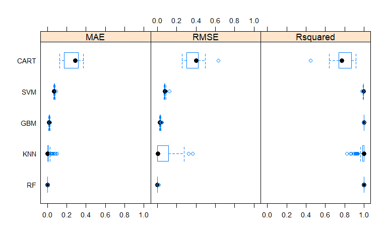

```r
bwplot(results)
```

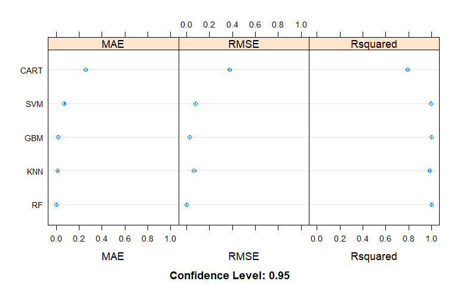

```r
dotplot(results)
```

## The optimal model identified

```r
fit_rf
```

```
Random Forest

801 samples
 23 predictor

No pre-processing
Resampling: Cross-Validated (10 fold, repeated 10 times)
Summary of sample sizes: 722, 720, 721, 721, 721, 720, ...
Resampling results across tuning parameters:

  mtry  splitrule   RMSE         Rsquared   MAE
   2    variance    0.006332098  0.9999493  0.0032786039
   2    extratrees  0.012526264  0.9998018  0.0070532331
  12    variance    0.001551015  0.9999931  0.0003737856
  12    extratrees  0.002231325  0.9999899  0.0006137542
  23    variance    0.001073034  0.9999929  0.0002288146
  23    extratrees  0.001709062  0.9999937  0.0004489523

Tuning parameter 'min.node.size' was held constant at a value of 5
RMSE was used to select the optimal model using the smallest value.
The final values used for the model were mtry = 23, splitrule = variance and min.node.size = 5.
```

```r
summary(fit_rf)
```

```
                          Length Class         Mode
predictions               801    -none-        numeric
num.trees                   1    -none-        numeric
num.independent.variables   1    -none-        numeric
mtry                        1    -none-        numeric
min.node.size               1    -none-        numeric
prediction.error            1    -none-        numeric
forest                      7    ranger.forest list
splitrule                   1    -none-        character
treetype                    1    -none-        character
r.squared                   1    -none-        numeric
call                        9    -none-        call
importance.mode             1    -none-        character
num.samples                 1    -none-        numeric
replace                     1    -none-        logical
xNames                     23    -none-        character
problemType                 1    -none-        character
tuneValue                   3    data.frame    list
obsLevels                   1    -none-        logical
param                       0    -none-        list
```

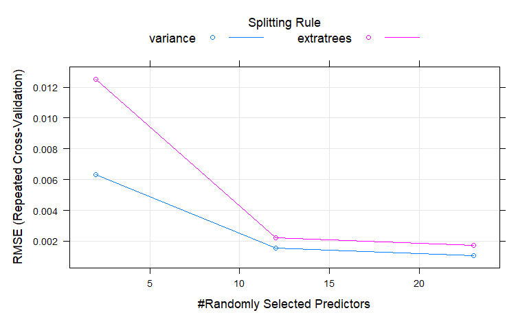

```r
plot(fit_rf)
```

```r
# predict and RMSE
predictions <- predict(fit_rf, test_set)
RMSE_rf <- RMSE(predictions, test_set$outcome)

# A result table is created to collect the RMSE results from different modelling
rmse_results <- data.frame(Method = "rf", RMSE = RMSE_rf) %>%  print()
```

| Method | RMSE |
| --- | --- |
| rf | 0.009824592 |